# Advanced_Analytics_Project_Classification2020

Reonne_A00268832

19 April 2020

## Classification on Ionosphere Dataset

##Dataset Information This radar data was collected by a system in Goose Bay, Labrador. This system consists of a phased array of 16 high-frequency antennas with a total transmitted power on the order of 6.4 kilowatts. See the paper for more details. The targets were free electrons in the ionosphere. “Good” radar returns are those showing evidence of some type of structure in the ionosphere. “Bad” returns are those that do not; their signals pass through the ionosphere.

Received signals were processed using an autocorrelation function whose arguments are the time of a pulse and the pulse number. There were 17 pulse numbers for the Goose Bay system. Instances in this databse are described by 2 attributes per pulse number, corresponding to the complex values returned by the function resulting from the complex electromagnetic signal.

1. Title: Johns Hopkins University Ionosphere database
2. Source Information: – Donor: Vince Sigillito (vgs@aplcen.apl.jhu.edu) – Date: 1989 – Source: Space Physics Group Applied Physics Laboratory Johns Hopkins University Johns Hopkins Road Laurel, MD 20723
3. Past Usage: – Sigillito, V. G., Wing, S. P., Hutton, L. V., & Baker, K. B. (1989). Classification of radar returns from the ionosphere using neural networks. Johns Hopkins APL Technical Digest, 10, 262-266.

   They investigated using backprop and the perceptron training algorithm on this database. Using the first 200 instances for training, which were carefully split almost 50% positive and 50% negative, they found that a “linear” perceptron attained 90.7%, a “non-linear” perceptron attained 92%, and backprop an average of over 96% accuracy on the remaining 150 test instances, consisting of 123 “good” and only 24 “bad” instances. (There was a counting error or some mistake somewhere; there are a total of 351 rather than 350 instances in this domain.) Accuracy on “good” instances was much higher than for “bad” instances. Backprop was tested with several different numbers of hidden units (in [0,15]) and incremental results were also reported (corresponding to how well the different variants of backprop did after a periodic number of epochs).

   David Aha (aha@ics.uci.edu) briefly investigated this database. He found that nearest neighbor attains an accuracy of 92.1%, that Ross Quinlan’s C4 algorithm attains 94.0% (no windowing), and that IB3 (Aha & Kibler, IJCAI-1989) attained 96.7% (parameter settings: 70% and 80% for acceptance and dropping respectively).
4. Relevant Information: This radar data was collected by a system in Goose Bay, Labrador. This system consists of a phased array of 16 high-frequency antennas with a total transmitted power on the order of 6.4 kilowatts. See the paper for more details. The targets were free electrons in the ionosphere. “Good” radar returns are those showing evidence of some type of structure in the ionosphere. “Bad” returns are those that do not; their signals pass through the ionosphere.

   Received signals were processed using an autocorrelation function whose arguments are the time of a pulse and the pulse number. There were 17 pulse numbers for the Goose Bay system. Instances in this databse are described by 2 attributes per pulse number, corresponding to the complex values returned by the function resulting from the complex electromagnetic signal.
5. Number of Instances: 351
6. Number of Attributes: 34 plus the class attribute – All 34 predictor attributes are continuous
7. Attribute Information:  
   – All 34 are continuous, as described above – The 35th attribute is either “good” or “bad” according to the definition summarized above. This is a binary classification task.
8. Missing Values: None

##Attribute Information – All 34 are continuous – The 35th attribute is either “good” or “bad” according to the definition summarized above. This is a binary classification task.

##Relevant paper Sigillito, V. G., Wing, S. P., Hutton, L. V., & Baker, K. B. (1989). Classification of radar returns from the ionosphere using neural networks. Johns Hopkins APL Technical Digest, 10, 262-266.

## Classification using Decision tree

Decision tree is a powerful tool for classification and prediction. It is a flowchart like tree structure where each of its internal nodes determine a test on an attribute, each branch represents an outcome of the test and each leaf node holds a class label. We will be using Decision Tree tp classify the “Ionosphere” dataset.

```r
library(rpart)
library(mlbench)
library(caTools)
```

#rpart Recursive partitioning for classification, regression and survival trees.

#mlbench A collection of artificial and real-world machine learning benchmark problems, including, e.g., several data sets from the UCI repository.

#caTools Contains several basic utility functions including: moving (rolling, running) window statistic functions, read/write for GIF and ENVI binary files, fast calculation of AUC, LogitBoost classifier, base64 encoder/decoder, round-off-error-free sum and cumsum, etc.

## Retrieving Dataset

```r
data('Ionosphere')
```

# Ionosphere dataset summary

```r
summary(Ionosphere)
```

```
##  V1      V2            V3                V4                 V5
##  0: 38   0:351   Min.   :-1.0000   Min.   :-1.00000   Min.   :-1.0000
##  1:313           1st Qu.: 0.4721   1st Qu.:-0.06474   1st Qu.: 0.4127
##                  Median : 0.8711   Median : 0.01631   Median : 0.8092
##                  Mean   : 0.6413   Mean   : 0.04437   Mean   : 0.6011
##                  3rd Qu.: 1.0000   3rd Qu.: 0.19418   3rd Qu.: 1.0000
##                  Max.   : 1.0000   Max.   : 1.00000   Max.   : 1.0000
##        V6                V7                V8                 V9
##  Min.   :-1.0000   Min.   :-1.0000   Min.   :-1.00000   Min.   :-1.00000
##  1st Qu.:-0.0248   1st Qu.: 0.2113   1st Qu.:-0.05484   1st Qu.: 0.08711
##  Median : 0.0228   Median : 0.7287   Median : 0.01471   Median : 0.68421
##  Mean   : 0.1159   Mean   : 0.5501   Mean   : 0.11936   Mean   : 0.51185
##  3rd Qu.: 0.3347   3rd Qu.: 0.9692   3rd Qu.: 0.44567   3rd Qu.: 0.95324
##  Max.   : 1.0000   Max.   : 1.0000   Max.   : 1.00000   Max.   : 1.00000
##       V10                V11                V12                V13
##  Min.   :-1.00000   Min.   :-1.00000   Min.   :-1.00000   Min.   :-1.0000
##  1st Qu.:-0.04807   1st Qu.: 0.02112   1st Qu.:-0.06527   1st Qu.: 0.0000
##  Median : 0.01829   Median : 0.66798   Median : 0.02825   Median : 0.6441
##  Mean   : 0.18135   Mean   : 0.47618   Mean   : 0.15504   Mean   : 0.4008
##  3rd Qu.: 0.53419   3rd Qu.: 0.95790   3rd Qu.: 0.48237   3rd Qu.: 0.9555
##  Max.   : 1.00000   Max.   : 1.00000   Max.   : 1.00000   Max.   : 1.0000
##       V14                V15               V16                V17
##  Min.   :-1.00000   Min.   :-1.0000   Min.   :-1.00000   Min.   :-1.0000
##  1st Qu.:-0.07372   1st Qu.: 0.0000   1st Qu.:-0.08170   1st Qu.: 0.0000
##  Median : 0.03027   Median : 0.6019   Median : 0.00000   Median : 0.5909
##  Mean   : 0.09341   Mean   : 0.3442   Mean   : 0.07113   Mean   : 0.3819
##  3rd Qu.: 0.37486   3rd Qu.: 0.9193   3rd Qu.: 0.30897   3rd Qu.: 0.9357
##  Max.   : 1.00000   Max.   : 1.0000   Max.   : 1.00000   Max.   : 1.0000
##       V18                 V19               V20                V21
##  Min.   :-1.000000   Min.   :-1.0000   Min.   :-1.00000   Min.   :-1.0000
##  1st Qu.:-0.225690   1st Qu.: 0.0000   1st Qu.:-0.23467   1st Qu.: 0.0000
##  Median : 0.000000   Median : 0.5762   Median : 0.00000   Median : 0.4991
##  Mean   :-0.003617   Mean   : 0.3594   Mean   :-0.02402   Mean   : 0.3367
##  3rd Qu.: 0.195285   3rd Qu.: 0.8993   3rd Qu.: 0.13437   3rd Qu.: 0.8949
##  Max.   : 1.000000   Max.   : 1.0000   Max.   : 1.00000   Max.   : 1.0000
##       V22                 V23               V24                V25
##  Min.   :-1.000000   Min.   :-1.0000   Min.   :-1.00000   Min.   :-1.0000
##  1st Qu.:-0.243870   1st Qu.: 0.0000   1st Qu.:-0.36689   1st Qu.: 0.0000
##  Median : 0.000000   Median : 0.5318   Median : 0.00000   Median : 0.5539
##  Mean   : 0.008296   Mean   : 0.3625   Mean   :-0.05741   Mean   : 0.3961
```

[output cut: 8 more lines]

```
##  Max.   : 1.00000   Max.   : 1.0000   Max.   : 1.00000   Max.   : 1.0000
##       V30                V31               V32                 V33
##  Min.   :-1.00000   Min.   :-1.0000   Min.   :-1.000000   Min.   :-1.0000
##  1st Qu.:-0.23689   1st Qu.: 0.0000   1st Qu.:-0.242595   1st Qu.: 0.0000
##  Median : 0.00000   Median : 0.4428   Median : 0.000000   Median : 0.4096
##  Mean   :-0.02791   Mean   : 0.3525   Mean   :-0.003794   Mean   : 0.3494
##  3rd Qu.: 0.15407   3rd Qu.: 0.8576   3rd Qu.: 0.200120   3rd Qu.: 0.8138
##  Max.   : 1.00000   Max.   : 1.0000   Max.   : 1.000000   Max.   : 1.0000
##       V34            Class
##  Min.   :-1.00000   bad :126
##  1st Qu.:-0.16535   good:225
##  Median : 0.00000
##  Mean   : 0.01448
##  3rd Qu.: 0.17166
##  Max.   : 1.00000
```

```r
str(Ionosphere)
```

```
## 'data.frame':    351 obs. of  35 variables:
##  $ V1   : Factor w/ 2 levels "0","1": 2 2 2 2 2 2 2 1 2 2 ...
##  $ V2   : Factor w/ 1 level "0": 1 1 1 1 1 1 1 1 1 1 ...
##  $ V3   : num  0.995 1 1 1 1 ...
##  $ V4   : num  -0.0589 -0.1883 -0.0336 -0.4516 -0.024 ...
##  $ V5   : num  0.852 0.93 1 1 0.941 ...
##  $ V6   : num  0.02306 -0.36156 0.00485 1 0.06531 ...
##  $ V7   : num  0.834 -0.109 1 0.712 0.921 ...
##  $ V8   : num  -0.377 -0.936 -0.121 -1 -0.233 ...
##  $ V9   : num  1 1 0.89 0 0.772 ...
##  $ V10  : num  0.0376 -0.0455 0.012 0 -0.164 ...
##  $ V11  : num  0.852 0.509 0.731 0 0.528 ...
##  $ V12  : num  -0.1776 -0.6774 0.0535 0 -0.2028 ...
##  $ V13  : num  0.598 0.344 0.854 0 0.564 ...
##  $ V14  : num  -0.44945 -0.69707 0.00827 0 -0.00712 ...
```

[output cut: 21 more lines]

```r
data <- Ionosphere
```

## Splitting dataset into training and Testing dataset

```r
samples <- sample.split(data$Class,SplitRatio = 0.75)
train_set <- subset(data,samples==TRUE)
test_set <- subset(data,samples==FALSE)
```

We take 75% of the data for training. We use this for prediction and testing. It is clear that if we take a higher percent of training data, we shall receive a higher accuracy for prediction. Next, we create a training model using rpart package with classification as the method for modeling.

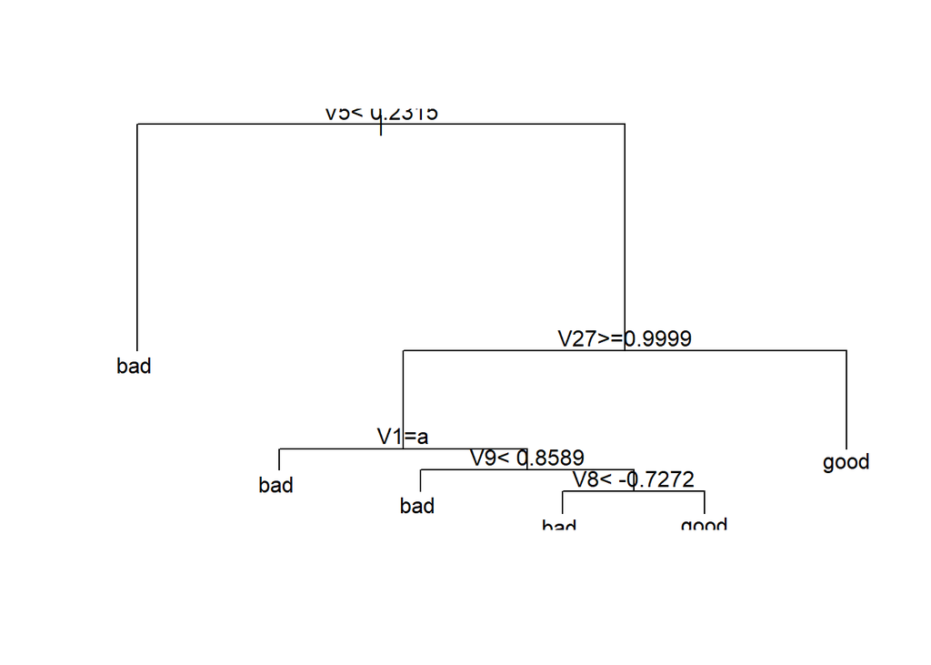

```r
modeling <- rpart(Class~.,data = train_set,method = 'class')
plot(modeling)
text(modeling)
```

# Model Prediction

Model prediction and score is calculated. We use the reamining 25% of the data for testing. The score collected is the mean of the values predicted. We create a table with the predicted and actual attributes. (The predicted attribute consists of the predicted values and the actual attribute consists of the actual data on the testing data set) From the table, we know that the model requires adjustments and improvements. Hence, we use cp to utilize values with which we get the minimum error value.

```r
model_predict <- predict(modeling,test_set[,-35],type = 'class')
score <- mean(model_predict==test_set$Class)
score
```

```
## [1] 0.8863636
```

```r
table(predicted=model_predict,actuals=test_set$Class)
```

```
##          actuals
## predicted bad good
##      bad   24    2
##      good   8   54
```

```r
cp <- which.min(modeling$cptable[,'xerror'])
cpt <- modeling$cptable[cp,'CP']
```

## Pruning the tree

Next, we proceed to pruning the data in order to improve the modeling and prediction. We prune the model created using the cpt variable which detected the minimum error value. We then proceed to prediction using the pruned model and get the pruned score, which is the mean of the pruned predicted values.

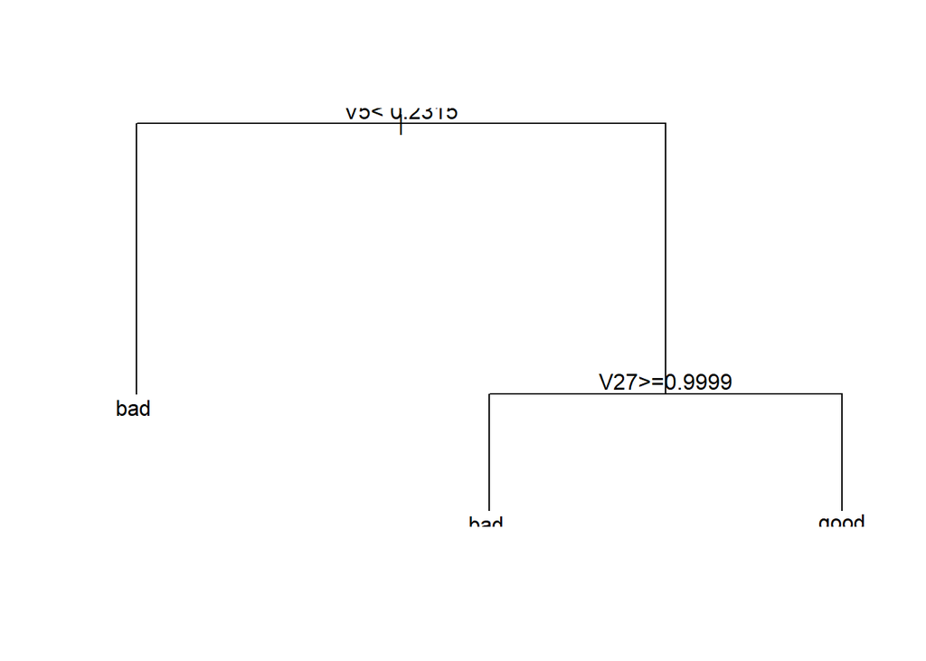

```r
pruned_modeling <- prune(modeling,cpt)
plot(pruned_modeling)
text(pruned_modeling)
```

```r
pruned_predict <- predict(pruned_modeling,test_set[,-35],type = 'class')
pruned_score <- mean(pruned_predict==test_set$Class)
pruned_score
```

```
## [1] 0.8863636
```

## Knn Classification of the Dataset

```r
library(rpart)
library(mlbench)
library(caTools)
```

## Retrieve the dataset

```r
dataurl <- ('http://archive.ics.uci.edu/ml/machine-learning-databases/ionosphere/ionosphere.data')
download.file(url = dataurl, destfile = "ionosphere.data")
ionosphere_df <- read.csv("ionosphere.data",header = FALSE,sep = ',')
View(ionosphere_df)
```

# Display the dataset retrieved

```r
str(ionosphere_df)
```

```
## 'data.frame':    351 obs. of  35 variables:
##  $ V1 : int  1 1 1 1 1 1 1 0 1 1 ...
##  $ V2 : int  0 0 0 0 0 0 0 0 0 0 ...
##  $ V3 : num  0.995 1 1 1 1 ...
##  $ V4 : num  -0.0589 -0.1883 -0.0336 -0.4516 -0.024 ...
##  $ V5 : num  0.852 0.93 1 1 0.941 ...
##  $ V6 : num  0.02306 -0.36156 0.00485 1 0.06531 ...
##  $ V7 : num  0.834 -0.109 1 0.712 0.921 ...
##  $ V8 : num  -0.377 -0.936 -0.121 -1 -0.233 ...
##  $ V9 : num  1 1 0.89 0 0.772 ...
##  $ V10: num  0.0376 -0.0455 0.012 0 -0.164 ...
##  $ V11: num  0.852 0.509 0.731 0 0.528 ...
##  $ V12: num  -0.1776 -0.6774 0.0535 0 -0.2028 ...
##  $ V13: num  0.598 0.344 0.854 0 0.564 ...
##  $ V14: num  -0.44945 -0.69707 0.00827 0 -0.00712 ...
```

[output cut: 21 more lines]

```r
dim(ionosphere_df)
```

```
## [1] 351  35
```

```r
summary(ionosphere_df)
```

```
##        V1               V2          V3                V4
##  Min.   :0.0000   Min.   :0   Min.   :-1.0000   Min.   :-1.00000
##  1st Qu.:1.0000   1st Qu.:0   1st Qu.: 0.4721   1st Qu.:-0.06474
##  Median :1.0000   Median :0   Median : 0.8711   Median : 0.01631
##  Mean   :0.8917   Mean   :0   Mean   : 0.6413   Mean   : 0.04437
##  3rd Qu.:1.0000   3rd Qu.:0   3rd Qu.: 1.0000   3rd Qu.: 0.19418
##  Max.   :1.0000   Max.   :0   Max.   : 1.0000   Max.   : 1.00000
##        V5                V6                V7                V8
##  Min.   :-1.0000   Min.   :-1.0000   Min.   :-1.0000   Min.   :-1.00000
##  1st Qu.: 0.4127   1st Qu.:-0.0248   1st Qu.: 0.2113   1st Qu.:-0.05484
##  Median : 0.8092   Median : 0.0228   Median : 0.7287   Median : 0.01471
##  Mean   : 0.6011   Mean   : 0.1159   Mean   : 0.5501   Mean   : 0.11936
##  3rd Qu.: 1.0000   3rd Qu.: 0.3347   3rd Qu.: 0.9692   3rd Qu.: 0.44567
##  Max.   : 1.0000   Max.   : 1.0000   Max.   : 1.0000   Max.   : 1.00000
##        V9                V10                V11                V12
##  Min.   :-1.00000   Min.   :-1.00000   Min.   :-1.00000   Min.   :-1.00000
##  1st Qu.: 0.08711   1st Qu.:-0.04807   1st Qu.: 0.02112   1st Qu.:-0.06527
##  Median : 0.68421   Median : 0.01829   Median : 0.66798   Median : 0.02825
##  Mean   : 0.51185   Mean   : 0.18135   Mean   : 0.47618   Mean   : 0.15504
##  3rd Qu.: 0.95324   3rd Qu.: 0.53419   3rd Qu.: 0.95790   3rd Qu.: 0.48237
##  Max.   : 1.00000   Max.   : 1.00000   Max.   : 1.00000   Max.   : 1.00000
##       V13               V14                V15               V16
##  Min.   :-1.0000   Min.   :-1.00000   Min.   :-1.0000   Min.   :-1.00000
##  1st Qu.: 0.0000   1st Qu.:-0.07372   1st Qu.: 0.0000   1st Qu.:-0.08170
##  Median : 0.6441   Median : 0.03027   Median : 0.6019   Median : 0.00000
##  Mean   : 0.4008   Mean   : 0.09341   Mean   : 0.3442   Mean   : 0.07113
##  3rd Qu.: 0.9555   3rd Qu.: 0.37486   3rd Qu.: 0.9193   3rd Qu.: 0.30897
##  Max.   : 1.0000   Max.   : 1.00000   Max.   : 1.0000   Max.   : 1.00000
##       V17               V18                 V19               V20
##  Min.   :-1.0000   Min.   :-1.000000   Min.   :-1.0000   Min.   :-1.00000
##  1st Qu.: 0.0000   1st Qu.:-0.225690   1st Qu.: 0.0000   1st Qu.:-0.23467
##  Median : 0.5909   Median : 0.000000   Median : 0.5762   Median : 0.00000
##  Mean   : 0.3819   Mean   :-0.003617   Mean   : 0.3594   Mean   :-0.02402
##  3rd Qu.: 0.9357   3rd Qu.: 0.195285   3rd Qu.: 0.8993   3rd Qu.: 0.13437
##  Max.   : 1.0000   Max.   : 1.000000   Max.   : 1.0000   Max.   : 1.00000
##       V21               V22                 V23               V24
##  Min.   :-1.0000   Min.   :-1.000000   Min.   :-1.0000   Min.   :-1.00000
##  1st Qu.: 0.0000   1st Qu.:-0.243870   1st Qu.: 0.0000   1st Qu.:-0.36689
##  Median : 0.4991   Median : 0.000000   Median : 0.5318   Median : 0.00000
##  Mean   : 0.3367   Mean   : 0.008296   Mean   : 0.3625   Mean   :-0.05741
```

[output cut: 8 more lines]

```
##  Max.   : 1.0000   Max.   : 1.00000   Max.   : 1.0000   Max.   : 1.00000
##       V29               V30                V31               V32
##  Min.   :-1.0000   Min.   :-1.00000   Min.   :-1.0000   Min.   :-1.000000
##  1st Qu.: 0.0000   1st Qu.:-0.23689   1st Qu.: 0.0000   1st Qu.:-0.242595
##  Median : 0.4966   Median : 0.00000   Median : 0.4428   Median : 0.000000
##  Mean   : 0.3784   Mean   :-0.02791   Mean   : 0.3525   Mean   :-0.003794
##  3rd Qu.: 0.8835   3rd Qu.: 0.15407   3rd Qu.: 0.8576   3rd Qu.: 0.200120
##  Max.   : 1.0000   Max.   : 1.00000   Max.   : 1.0000   Max.   : 1.000000
##       V33               V34           V35
##  Min.   :-1.0000   Min.   :-1.00000   b:126
##  1st Qu.: 0.0000   1st Qu.:-0.16535   g:225
##  Median : 0.4096   Median : 0.00000
##  Mean   : 0.3494   Mean   : 0.01448
##  3rd Qu.: 0.8138   3rd Qu.: 0.17166
##  Max.   : 1.0000   Max.   : 1.00000
```

# Splitting data into Training and Testing set

```r
set.seed(200)
ionosphere_df <- ionosphere_df[sample(nrow(ionosphere_df)),]
traindata.df <- ionosphere_df[1:as.integer(0.75*351),]
testdata.df <- ionosphere_df[as.integer(0.75*351 + 1):351,]
```

Euclidean Distance is calculated to find how the data points are related with each other and classifying the data according to the distance. We calculate the euclidean distance manually through function creation. The function takes two parameters x and y and returns a variable dt which is the euclidean distance.

```r
euclideandist <- function(x,y){
  dt = 0
  for(i in c(1:(length(x)-1)))
    {
      dt = dt + (x[[i]]-y[[i]])^2
  }
  dt = sqrt(dt)
  return(dt)
}
```

# Building the knn Model

We then build the model for knn classification. Three parameters are for the function; the training data, test data and the k-value varaible, kval. The function has three loops: First loop is to iterate through the test data. Second loop is nested within the first loop and it iterates through the training data. The second loop calculates the euclidean distance between the test datapoints and the training data points. The second loop also returns a character variable to check for whether the prediction is “g” or “b” [eucchar gets whether the output is “good” or “bad”]. After the second loop, a variable “euc”, which is a data frame of the euclidean distance values retrieved and the euclidean output (good or bad), is created. The third loop iterates through this data frame, which is ordered before iteration, and calculates how many good and bad outputs are present through a simple if- else sequence. If the number of good is greater than number of bad, then “pred” (output attribute) is given “g” and vice versa. The pred variable is returned.

```r
knn_predict <- function(testdata,traindata,kval){
  pred <- c()
  for(i in c(1:nrow(testdata))){
    eucdist = c()
    eucchar = c()
    good = 0
    bad = 0

    for(j in c(1:nrow(traindata))){
      eucdist <- c(eucdist,euclideandist(testdata[i,],traindata[j,]))
      eucchar <- c(eucchar,as.character(traindata[j,][[35]]))
    }

    euc <- data.frame(eucchar,eucdist)
    euc <- euc[order(euc$eucdist),]
    euc <- euc[1:kval,]

    for(k in c(1:nrow(euc))){
      if(as.character(euc[k,"eucchar"]) == "g"){
        good = good + 1
      }
      else
        bad = bad + 1
    }
    if(good>bad){
      pred <- c(pred,"g")
    }
    else if(good<bad){
      pred <- c(pred,"b")
    }
  }
  return(pred)
}
```

# Accuracy

We need to calculate the accuracy of this knn algorithm and for this purpose we create another function for checking the output “pred” with the actual output “g” or “b” in the actual dataset. If the comparison aims to be true and accurate then the value for varaible “correct” and finally we average it and get the percentage.

```r
accuracyval <- function(testdata){
  correct = 0
  for(i in c(1:nrow(testdata))){
    if(testdata[i,35] == testdata[i,36]){
      correct = correct + 1
    }
  }
  accuval = correct/nrow(testdata)*100
  return(accuval)
}
```

We take the K value as 5 and then predict using the knn prediction model created earlier. The predictions are added as an attribute to the test data set. We then use the accuracy measure function and calculate the accuracy of the predicted data.

[output not shown]

The accuracy is 84.09%, which is fairly good, but could be improved.

## Knn Classification using Caret

Packages required: Caret and e1071

```r
library(caret)
library(e1071)
```

## Retrieving dataset

```r
dataurl <- ('http://archive.ics.uci.edu/ml/machine-learning-databases/ionosphere/ionosphere.data')
download.file(url = dataurl, destfile = "ionosphere.data")
ionosphere_df <- read.csv("ionosphere.data",header = FALSE,sep = ',')
```

## Splitting Training and Testing dataset

We first check for any missing values in the dataset, then split it into testing and training datasets.

```r
set.seed(3000)
initrain <- createDataPartition(y = ionosphere_df$V1, p=0.7, list = FALSE)
trainingdata <- ionosphere_df[initrain,]
testingdata <- ionosphere_df[-initrain,]
```

We have split the dataset into testing an training data. We use 70% of the dataset for training the model. The rest we use for testing the model. # Getting the dimensions of the training and testing dataset

```r
dim(trainingdata)
```

```
## [1] 246  35
```

```r
dim(testingdata)
```

```
## [1] 105  35
```

We check the dimensions of the testing and training data for for loops and data scaling.

# Training model

We create a control for the iterations for the training model. The resampling method we use is repeated cross-validation, therefore, there is a number of repetitve cross checking. Here we specify 6 repeats.“Repeats” refer to the number of resampling iterations.The entire function controls the computational nuances of the train function.

```r
anyNA(ionosphere_df)
```

```
## [1] FALSE
```

```r
trainingdata[["V1"]] = factor(trainingdata[["V1"]])
trnControl <- trainControl(method = "repeatedcv",number = 20,repeats = 6)
```

# Building the model

A training model is built and we use the training data. We use the knn method for classification and have a tunelength of 10.

```r
set.seed(4000)
knn_df <- train(V1~.,data = trainingdata, method = "knn",
                trControl = trnControl,
                preProcess = c("center","scale"),
                tuneLength = 10)
knn_df
```

```
## k-Nearest Neighbors
##
## 246 samples
##  34 predictor
##   2 classes: '0', '1'
##
## Pre-processing: centered (34), scaled (34)
## Resampling: Cross-Validated (20 fold, repeated 6 times)
## Summary of sample sizes: 233, 234, 234, 234, 233, 234, ...
## Resampling results across tuning parameters:
##
##   k   Accuracy   Kappa
##    5  0.8891900  0.196154471
##    7  0.8881119  0.003114177
##    9  0.8914773  0.000000000
##   11  0.8914773  0.000000000
##   13  0.8914773  0.000000000
##   15  0.8914773  0.000000000
##   17  0.8914773  0.000000000
##   19  0.8914773  0.000000000
##   21  0.8914773  0.000000000
##   23  0.8914773  0.000000000
##
## Accuracy was used to select the optimal model using the largest value.
## The final value used for the model was k = 23.
```

## Prediction

We use the model for prediction of the test dataset.

```r
testprediction <- predict(knn_df,newdata = testingdata)
View(testprediction)
#testingdata[,36] <- testprediction
View(testingdata$V1)

#print(accuracyval(testingdata))
#confusionMatrix(testprediction,testingdata$V1)
```